# Examining Race Imputation of Mothers in CDC Natality Records

Thomas Laetsch

9/16/2020

## Introduction

In 2018, the CDC recorded approximately 3,800,000 births; the records can be found [here](https://www.cdc.gov/nchs/data_access/vitalstatsonline.htm#Downloadable). Among the over 100 features recorded per birth, one of the features tracks the race of the mother with roughly 6.3% (on the order of 250,000) of those records imputed. According to the CDC, their method of imputation is (from pg 54 of here) “*Where race of the mother is not reported, if the race of the father is known, the race of the father is assigned to the mother. When information is not available for either parent, the race of the mother is imputed according to the specific race of the mother on the preceding record with a known race of mother.*” In these notes, we investigate the legitimacy of this imputation method, discuss the bias, and consider the populations of those mothers whose race is not reported versus those where it is. Beyond these notes, we also create a machine learning model in Python, trying to improve the representation within the group of mothers where race is not reported.

For these notes, our goal is not to give a full treatise on every distinction between the populations of mother’s with and without race being recorded, but instead to provide evidence that the current imputation practice may benefit from review since it is apparent that there are distinctions and that the current system may tend to bias the data towards labelling the unknown race as “white”, the majority race recorded, though this cannot be proved without knowing the truth of the missing records.

## Loading the Dataset and Libraries

For convenience, the majority of exploration in these notes will be from a randomly selected 10% of the 2018 CDC data, found in `data/Birth18_10per.csv`. The potential bias introduced through such subsetting is discussed below, as is evidence that the over 380,000 records we will use is reasonably representative for our purposes.

```r
library(dplyr)
library(readr)
library(ggplot2)
```

```r
# Read in the dataset as a tibble using readr::read_csv
nat18 = read_csv('https://graderdata.s3.amazonaws.com/Birth18_10per.csv')
# Look at some of the features
colnames(nat18)[1:50]
```

```
##  [1] "birth_year"                     "birth_month"
##  [3] "birth_time"                     "birth_day_of_wk"
##  [5] "birth_place"                    "mothers_age_imputed"
##  [7] "mothers_age"                    "mothers_nativity"
##  [9] "mothers_residence_status"       "mothers_race31"
## [11] "mothers_race6"                  "mothers_race15"
## [13] "mothers_race_bridged"           "mothers_race_imputed"
## [15] "mothers_hispanic_origin"        "mothers_hispanic_origin_recode"
## [17] "paternity_acknow"               "mothers_marital_status"
## [19] "mothers_maristat_imputed"       "mothers_education"
## [21] "fathers_age"                    "fathers_race31"
## [23] "fathers_race6"                  "fathers_race15"
## [25] "fathers_hispanic_origin"        "fathers_hispanic_origin_recode"
## [27] "fathers_education"              "prior_living_births"
## [29] "prior_dead_births"              "prior_terminations"
## [31] "mo_since_last_live_birth"       "mo_since_last_other_birth"
## [33] "mo_prenatal_care_began"         "n_prenatal_visits"
## [35] "wic"                            "cigs_tri1"
## [37] "cigs_tri2"                      "cigs_tri3"
## [39] "mothers_height"                 "mothers_bmi"
## [41] "pre_preg_lbs"                   "delivery_lbs"
## [43] "pre_preg_diab"                  "gest_diab"
## [45] "pre_preg_hypten"                "gest_hypten"
## [47] "hypten_ecl"                     "prev_preterm_birth"
## [49] "infertility_treatment"          "fertil_enhance"
```

## Subsetting and Cleaning

From the many features we see above, we will only focus on a few. This is not to suggest that there is no use or information in the other columns, but rather we keep an intuitive and managable few for this discussion which still have the illustrative power we need. We also benefit from the features relying mostly on the mother The features we keep here are

- `mothers_race_imputed`: This is the main feature which distinguishes the two populations we compare. We will coerce this into logical type.
- `mothers_race6`: Six-level integer feature indicating the mother’s race based on the recode found here. To note, there are two other recodes of race with 31 and 15 levels, respectively, but for these notes, we will only consider the six-level feature. More finely grained exploration can and should be carried out at the other levels. This is the feature we want to examine the CDC imputation process of.
- `mothers_age`: Numeric type, giving the mother’s age in years.
- `mothers_height`: Numeric type, giving the mother’s height in inches.
- `mothers_bmi`: Numeric type, giving the mother’s approximate body mass index.
- `mothers_nativity`: Three-level integer feature indicating where the mother was born with 1 meaning in the US, 2 meaning outside of the US, and 3 meaning it is unknown.
- `mothers_residence_status`: Four-level integer feature indicating the mother’s residency at the state and county level relative to the occurence of the birth. Here 1-3 indicate that the mother is a US resident, but vary on whether the residency matches the state and county of the birth; 4 indicates that the mother is not a US resident (but the birth still takes place within the US).
- `mothers_education`: Nine-level integer feature indicating the mothers education level, with 1-8 representing increasing amounts of schooling, and 9 representing unknown.
- `fathers_race6`: Father’s analog of `mothers_race6` with an extra level of 9 indicating the race is unknown in the record. This distinction is because the mother’s race is always imputed if missing, but the father’s is not.

These data are already mostly cleaned and formatted in a way that we can use, with the exception of `mothers_race_imputed` which is `NA` when there is no imputation, otherwise `"1"`. So, the cleaning at this stage could simply be subsetting the features and coercing `mothers_race_imputed` into logical type, but we also coerce all other features except BMI into int type since when reading them in, they defaulted to float, but naturally are int.

```r
# Create a cleaning function, for easy reproducibility.
nat_col_clean = function(natdf){
  # Subset the features
  keep_cols = c('mothers_race_imputed',
                'mothers_race6',
                'mothers_age',
                'mothers_height',
                'mothers_bmi',
                'mothers_nativity',
                'mothers_residence_status',
                'mothers_education',
                'fathers_race6')
  natdf = natdf[keep_cols]
  # Coerce mothers_race_imputed to logical
  natdf$mothers_race_imputed = !is.na(natdf$mothers_race_imputed)
  # Coerce to int type
  natdf$mothers_race6 = as.integer(natdf$mothers_race6)
  natdf$mothers_age = as.integer(natdf$mothers_age)
  natdf$mothers_height = as.integer(natdf$mothers_height)
  natdf$mothers_nativity = as.integer(natdf$mothers_nativity)
  natdf$mothers_residence_status = as.integer(natdf$mothers_residence_status)
  natdf$mothers_education = as.integer(natdf$mothers_education)
  natdf$fathers_race6 = as.integer(natdf$fathers_race6)
  # return
  natdf
}

# Clean nat18
nat18 = nat_col_clean(nat18)
# Glimpse at structure
glimpse(nat18)
```

```
## Rows: 381,372
## Columns: 9
## $ mothers_race_imputed     <lgl> FALSE, FALSE, FALSE, FALSE, FALSE, FALSE, FA…
## $ mothers_race6            <int> 1, 3, 1, 1, 1, 1, 1, 1, 1, 1, 1, 1, 1, 4, 1,…
## $ mothers_age              <int> 26, 29, 36, 21, 22, 31, 27, 22, 29, 34, 35, …
## $ mothers_height           <int> 69, 60, 66, 66, 63, 68, 63, 67, 65, 67, 64, …
## $ mothers_bmi              <dbl> 19.8, 26.4, 27.4, 29.0, 23.0, 28.9, 21.3, 29…
## $ mothers_nativity         <int> 1, 1, 1, 1, 1, 1, 1, 1, 1, 1, 1, 1, 1, 2, 1,…
## $ mothers_residence_status <int> 1, 2, 1, 1, 1, 1, 1, 1, 1, 1, 1, 1, 1, 1, 1,…
## $ mothers_education        <int> 7, 2, 6, 4, 3, 6, 4, 4, 4, 7, 7, 6, 4, 4, 4,…
## $ fathers_race6            <int> 1, 3, 1, 3, 1, 1, 1, 1, 1, 4, 1, 1, 1, 1, 1,…
```

## The CDC’s Imputation

According to the CDC documentation, we expect that if the father’s race is known, the mother’s race will be imputed as the same. We will examine this, before starting we engineer a new feature whether or not the father’s race is assigned to the mother.

```r
nat18$fathers_race_assigned = (nat18$fathers_race6 != 9)
```

From here, let’s check that we agree with the documentation

```r
mask = (nat18$mothers_race_imputed & nat18$fathers_race_assigned)
# Calc the percentage of matching between mother's and father's race
per = 100*mean(nat18[mask,]$mothers_race6 == nat18[mask,]$fathers_race6)
cat(sprintf("The percentage match between imputed race is %.2f%s", per,"%"))
```

```
## The percentage match between imputed race is 95.31%
```

The fact that this isn’t 100% seems a bit disturbing since it means something else is happening for a small group of imputed races, even when the father’s race is known. From here, we can distill which of the known father’s races are being labelled as something different for the mother.

```r
nat18[mask,] %>%
      group_by(fathers_race6, mothers_race6) %>%
      summarise(n = n())
```

```
## # A tibble: 10 x 3
## # Groups:   fathers_race6 [6]
##    fathers_race6 mothers_race6     n
##            <int>         <int> <int>
##  1             1             1  2982
##  2             2             2   952
##  3             3             3    72
##  4             4             4   189
##  5             5             5    57
##  6             6             1   177
##  7             6             2    22
##  8             6             3     2
##  9             6             4     7
## 10             6             5     1
```

It’s clear that when the father’s race is labeled 6, the mother’s race label is also not imputed with the father’s. Looking at the documentation here, we see that this value represents when the father is identified as more than one race, so apparently the CDC does not want to use such a labeling to impute the mother’s race. Moreover, we should notice that the only levels imputed for the mother are 1-5, there is not a single imputed value of 6. So, it seems clear that we should revise our understanding of the CDC’s imputation strategy to something along the lines of “*Where race of the mother is not reported, if the race of the father is known and can be assigned unambiguously to a single race, that race is assigned to the mother.*”

This begs us to redefine our engineered column.

```r
# Create a function to make fathers_race_assigned col, for easy reproducibility.
nat_fathers_race_assigned = function(natdf){
  natdf$fathers_race_assigned = (natdf$fathers_race6 < 6)
  natdf
}

# Update df
nat18 = nat_fathers_race_assigned(nat18)
```

With that, let’s visualize some justification for the imputation by father’s race. We do this in two ways, both of which will be restricted to cases where the mother’s race is known, but would be imputed by the father’s race if it were not. First, we quickly ask the accuracy of this imputation strategy on this subset; second, we visualize the distribution of race between the mother and father within this group.

```r
m_and_f = nat18[(!nat18$mothers_race_imputed) & nat18$fathers_race_assigned, ]
acc = mean(m_and_f$mothers_race6 == m_and_f$fathers_race6)
print(sprintf("The accuracy of the father assignment when possible is %.2f%s",100*acc,"%"))
```

```
## [1] "The accuracy of the father assignment when possible is 91.33%"
```

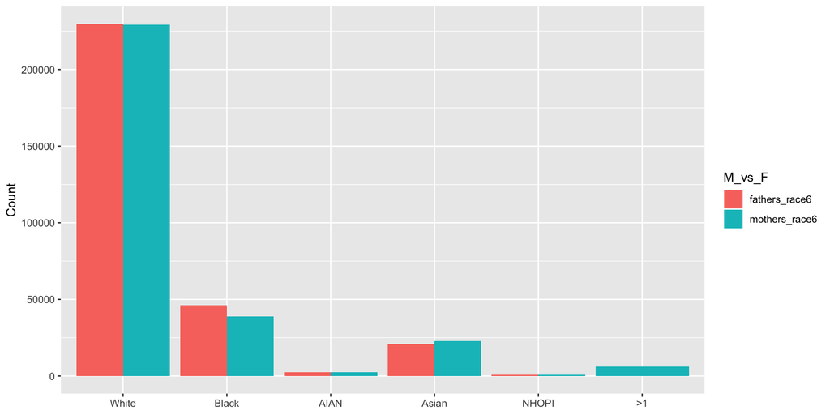

```r
# Bar chart to consider race assignment distributions
m_and_f %>% select(mothers_race6, fathers_race6) %>%
      tidyr::pivot_longer(cols=c('mothers_race6','fathers_race6'),
                                names_to = "M_vs_F",
                                values_to = "race_label") %>%
      ggplot(aes(x = factor(race_label), group = M_vs_F, fill = M_vs_F)) +
      geom_bar(position = "dodge") +
      scale_x_discrete(labels=c('White','Black','AIAN','Asian','NHOPI','>1')) +
      xlab(NULL) + ylab('Count')
```

What we see is that while not perfect, the imputation by the father’s race is not unjustified either as it seems to work largely as a surrogate within the sample where we can actually check.

We do not check that the CDC actually follows the latter claimed strategy (“*When information is not available for either parent, the race of the mother is imputed according to the specific race of the mother on the preceding record with a known race of mother*”), since that would require more work than we need immediately, and certainly not easily attainable from our subset.

#### First Comparisons Between Imputed vs Given Race Distributions

Finally, we end this section by considering the distribution of races of the mother, considering the two groups where the race was imputed and where it was not.

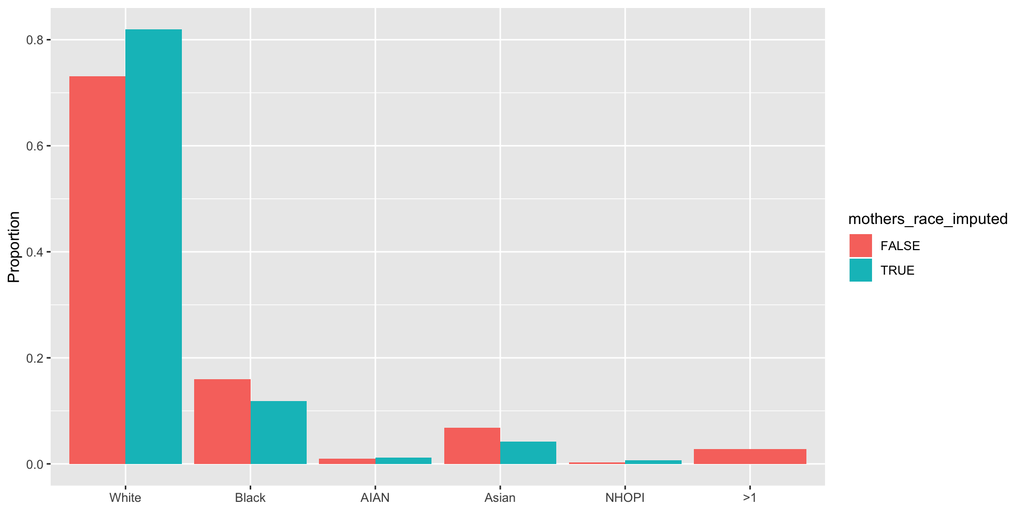

```r
# Summarise the proportional distribution amongst race groups
comp_yn_imp = nat18 %>%
      group_by(mothers_race6, mothers_race_imputed) %>%
      summarise(count = n()) %>%
      group_by(mothers_race_imputed) %>%
      mutate(perc_race = count/sum(count))

# Create a bar plot to illustrate
comp_yn_imp %>%
      ggplot(aes(x=factor(mothers_race6),
                 y=perc_race,
                 group=mothers_race_imputed,
                 fill=mothers_race_imputed)) +
      geom_bar(stat='identity', position='dodge') +
      scale_x_discrete(labels=c('White','Black','AIAN','Asian','NHOPI','>1')) +
      xlab(NULL) + ylab('Proportion')
```

It is apparent from above that the imputed race for the mother tends to be *White* relative to the other possible race labels. It appears that it is skewed towards *White* even if we were to accidentally assign all $>1$ labels to *White*.

We should ask if this is a result of the distribution of known races of the father, when we impute. It could be, for example, that among the population of mothers whose race needs to be imputed, it happens that the known father’s race is more heavily skewed *White*, potentially suggesting that *White* would be a more common label among the race-imputed population. For that, we will plot the bar charts for each race in three groups: the race is not imputed, the race is imputed and the father’s race is used, and the race is imputed but the father’s race is not used. This should give us a feeling among the race-imputed group where the imputation skewing is coming from. Since we will create this bar chart for a future dataset, we place the code into a function for portability.

```r
compare_yn_fath_grps = function(natdf){
  # Summarise the proportional distribution among imputed between y/n uses father's race
  comp_yn_fath = natdf[natdf$mothers_race_imputed,] %>%
  group_by(mothers_race6,fathers_race_assigned) %>%
  summarise(count = n()) %>%
  group_by(fathers_race_assigned) %>%
  mutate(perc_race = count/sum(count))

  # Create 3 groups: not imputed, is imputed from father, is imputed w/o father
  comp_yn_imp = comp_yn_imp[!comp_yn_imp$mothers_race_imputed, ]
  comp_yn_imp$group = 'Not imputed'
  comp_yn_fath$group = ''
  comp_yn_fath$group[comp_yn_fath$fathers_race_assigned] = 'Imputed from father'
  comp_yn_fath$group[!comp_yn_fath$fathers_race_assigned] = 'Imputed w/o father'

  # Rbind the two dfs together so three groups land in single data frame
  plot_cols = c('mothers_race6','group','perc_race')
  comp_tot = rbind(comp_yn_imp[plot_cols], comp_yn_fath[plot_cols])

  # Bar plot the result
  comp_tot %>%
        ggplot(aes(x=factor(mothers_race6),
                   y=perc_race,
                   group=group,
                   fill=group)) +
        geom_bar(stat='identity', position='dodge') +
        scale_x_discrete(labels=c('White','Black','AIAN','Asian','NHOPI', '>1')) +
        xlab(NULL) + ylab('Proportion')
}
```

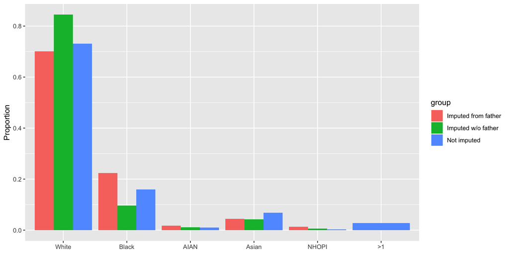

```r
compare_yn_fath_grps(nat18)
```

This is surprising, and our first real evidence that perhaps the CDC may need to reconsider their imputation strategy. Notice that the skewing towards *White* in the imputed race labels is driven heavily by the imputation without using the father’s race, largely at the cost of the weight on *Black*. Moreover, among the group who are assigned the father’s race, the wieght on non- *White* labels is higher than the distribution among the non-imputed group.

Finally, we create one more plot which considers a point that might justify the “*White* skewing” we just witnessed. The argument would be that if you look amongst the mothers whose lables are known and consider the distributions of race between those where the father’s race would and would not be imputed, then the difference between those two might resemble what we’ve seen in the imputed group. However, this is not the case.

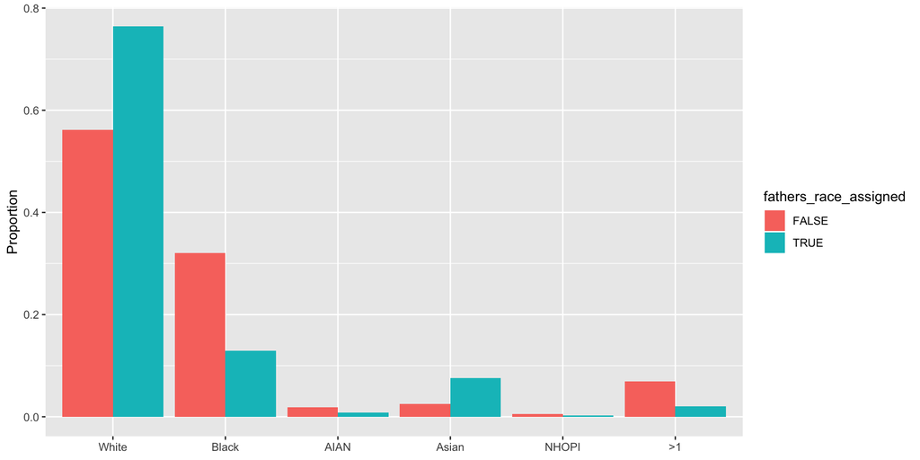

```r
nat18[!nat18$mothers_race_imputed,] %>%
      group_by(mothers_race6,fathers_race_assigned) %>%
      summarise(count = n()) %>%
      group_by(fathers_race_assigned) %>%
      mutate(perc_race = count/sum(count)) %>%
      ggplot(aes(x=factor(mothers_race6),
                 y=perc_race,
                 group=fathers_race_assigned,
                 fill=fathers_race_assigned)) +
      geom_bar(stat='identity', position='dodge') +
      scale_x_discrete(labels=c('White','Black','AIAN','Asian','NHOPI','>1')) +
      xlab(NULL) + ylab('Proportion')
```

In fact, we see that the trend is the opposite as that in the CDC imputation strategy. Among known labels, when the father’s race would not be assigned, the distribution has significantly less weight on *White* and *Asian*, with more weight on *Black* and *>1*!

## Comparing the Distinctions Between Distributions

The previous section provides evidence that the imputation strategy by the CDC, at least when the father’s race is unknown, creates bias, heavily skewing towards *White*. In this section we consider deeper that even if we were to try to mimic the distribution of the known race labels for the mother, it might not be justified. In fact, our argument is that these populations of individuals are significantly different, where beyond by-eye graphs, we use statistical tests to show that along some features, the two groups are measurably distinct.

We will lean heavy on the [Kolmogorov-Smirnov Test](https://en.wikipedia.org/wiki/Kolmogorov%E2%80%93Smirnov_test). Roughly, what this test does is ask “how far apart are the cumulative distributions between two samples?” The point is that if the cumulative distributions are far apart, it suggests that the two sample distributions are drawn from different populations, and there is way to check the significance of this claim through the familiar “p-value”, though we will not delve too deeply into the theoretical weeds here.

We will be using the `stats` function `ks.test` a fair amount in what follows. There will be two values we will keep our eyes on: the `statistic` $D$ and the `p.value`. The statistic $D$ ranges between 0 and 1, measuring the uniform distance between the approximate cumulative distributions of each sample, with a meaning that the larger the number, the more disparate the distributions are. The `p.value` asks how significantly different is $D$ from $0$, where $0$ would indicatate that the cumulative distributions are the same, and hence the samples were drawn from the same distribution.

In terms of hypothesis testing, the null-hypothesis is that $D = 0$ and we want to decide whether or not we should reject the null-hypothesis. Rejecting the null-hypothesis then is rejecting that the two samples were drawn from the same distribution.

Before continuing, we will write a wrapper function to format a nice printout for running `ks.test`.

```r
ks.test_printout = function(samp1, samp2){
  ks = ks.test(samp1, samp2)
  D = ks$statistic
  pval = ks$p.value
  print(sprintf("The statistic D=%.4f with p-value=%.6f", D, pval))
  ks
}
```

#### Mothers’ Ages

Calculating some basic statistics, we see that the average age of mothers whose race was imputed is slightly younger on average than those mothers whose age was not imputed. However, the difference in average and median age isn’t gaping.

```r
nat18 %>% select(mothers_race_imputed, mothers_age) %>%
      group_by(mothers_race_imputed) %>%
      summarise(age_mu = mean(mothers_age),
                age_med = median(mothers_age),
                age_sig2 = var(mothers_age))
```

```
## # A tibble: 2 x 4
##   mothers_race_imputed age_mu age_med age_sig2
##   <lgl>                 <dbl>   <int>    <dbl>
## 1 FALSE                  29.0      29     33.3
## 2 TRUE                   28.6      28     39.8
```

Instead, what we notice by looking at the distribution is that the mothers whose race was imputed is apparently differently distributed, with slightly more variance and ostensibly more symmetric around its mean when compared to the other group.

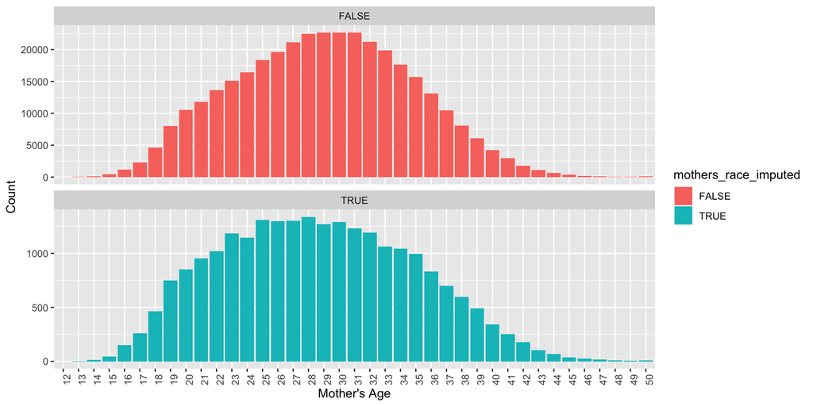

```r
nat18 %>%
      ggplot(aes(x=factor(mothers_age),
                 fill = mothers_race_imputed)) +
      geom_bar() +
      facet_wrap(~mothers_race_imputed, ncol = 1, scales = "free_y") +
      theme(axis.text.x = element_text(angle = 90)) +
      xlab("Mother's Age") + ylab('Count')
```

This difference in distribution is what we want to measure, which leads us naturally to the KS-test.

```r
ks_age = ks.test_printout(nat18[nat18$mothers_race_imputed,]$mothers_age,
                          nat18[!nat18$mothers_race_imputed,]$mothers_age)
```

```
## [1] "The statistic D=0.0550 with p-value=0.000000"
```

Here, `D` is reasonably small, but with such a small p-value, it still indicates that the distinction is significant.

#### Mothers’ Heights

Much more apparent than the age distinction, the two populations of mothers have noticeable difference in height distributions, where those mothers whose race was imputed tend to be a bit shorter on average, but also seems to have a heavier tail towards the shorter end of the spectrum.

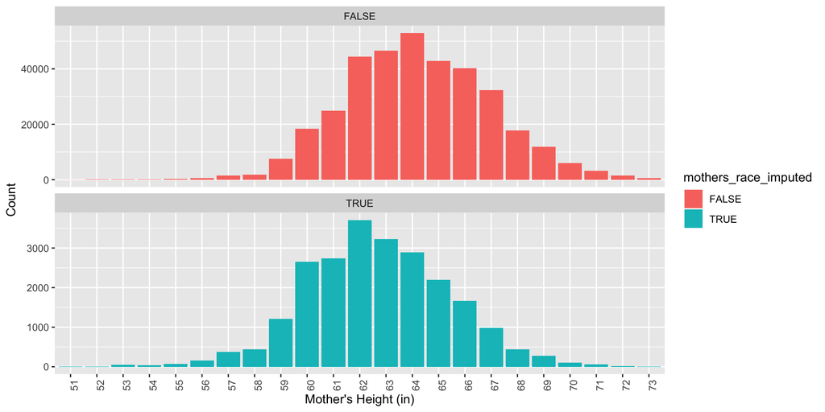

```r
nat18 %>%
      filter((mothers_height > 50) & (mothers_height < 74)) %>%
      ggplot(aes(x=factor(mothers_height),
                 fill = mothers_race_imputed)) +
      geom_bar() +
      facet_wrap(~mothers_race_imputed, ncol = 1, scales = "free_y") +
      theme(axis.text.x = element_text(angle = 90)) +
      xlab("Mother's Height (in)") + ylab('Count')
```

As before, we compare a couple descriptive statistics to consider this trend, and again it doesn’t seem gaping.

```r
known_height = nat18[nat18$mothers_height < 99, ]
known_height %>%
      select(mothers_race_imputed, mothers_height) %>%
      group_by(mothers_race_imputed) %>%
      summarise(height_mu = mean(mothers_height),
                height_med = median(mothers_height),
                height_sig2 = var(mothers_height))
```

```
## # A tibble: 2 x 4
##   mothers_race_imputed height_mu height_med height_sig2
##   <lgl>                    <dbl>      <dbl>       <dbl>
## 1 FALSE                     64.2         64        7.88
## 2 TRUE                      62.7         63        7.94
```

However, the KS-test is much more determined in this feature to point out a distinction. You’ll notice below that the `D` statistic is much larger than it was for the mothers ages, suggesting that the distribution of heights is quite distinguishing between the populations.

```r
ks_height =
  ks.test_printout(known_height[known_height$mothers_race_imputed,]$mothers_height,
                   known_height[!known_height$mothers_race_imputed,]$mothers_height)
```

```
## [1] "The statistic D=0.2183 with p-value=0.000000"
```

#### Mothers’ Weights

From the body mass index (BMI) and height, we can calculate the weights (see [here](https://www.cdc.gov/healthyweight/assessing/bmi/adult_bmi/index.html#Interpreted)). We won’t spend much time discussing the distinction in distributions other than mentioning here that it seems the variance difference is a distinguishing factor.

```r
known_height$mothers_weight = (known_height$mothers_height**2/703)*known_height$mothers_bmi

known_height = known_height %>% filter(mothers_weight < 400)

known_height %>% select(mothers_race_imputed, mothers_weight) %>%
      group_by(mothers_race_imputed) %>%
      summarise(weight_mu = mean(mothers_weight),
                weight_med = median(mothers_weight),
                weight_sig2 = var(mothers_weight))
```

```
## # A tibble: 2 x 4
##   mothers_race_imputed weight_mu weight_med weight_sig2
##   <lgl>                    <dbl>      <dbl>       <dbl>
## 1 FALSE                     160.       150.       1786.
## 2 TRUE                      153.       145.       1331.
```

Visualize the distributions:

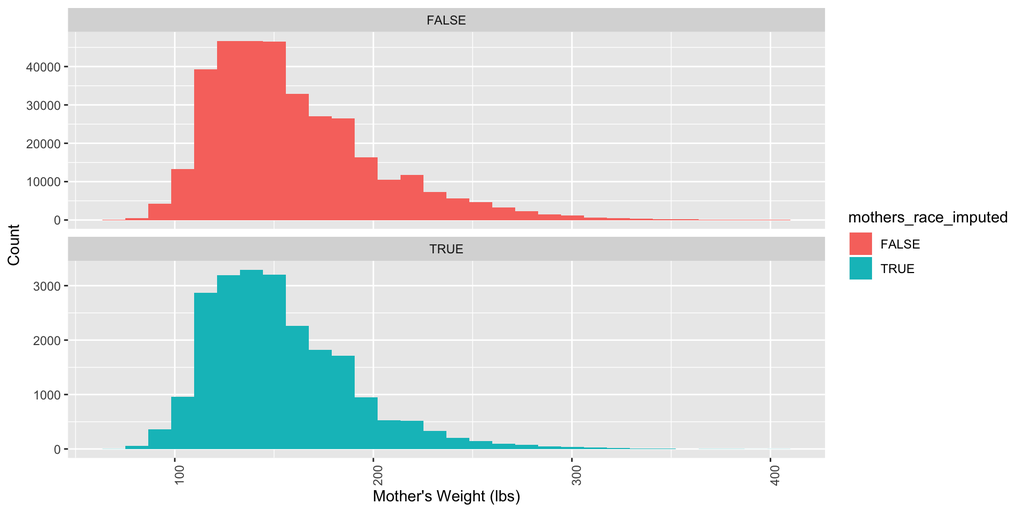

```r
known_height %>%
      ggplot(aes(x=mothers_weight, fill = mothers_race_imputed)) +
      geom_histogram() +
      facet_wrap(~mothers_race_imputed, ncol = 1, scales = "free_y") +
      theme(axis.text.x = element_text(angle = 90)) +
      xlab("Mother's Weight (lbs)") + ylab('Count')
```

The KS-test results:

```r
ks_weight =
  ks.test_printout(known_height[known_height$mothers_race_imputed,]$mothers_weight,
                   known_height[!known_height$mothers_race_imputed,]$mothers_weight)
```

```
## [1] "The statistic D=0.0619 with p-value=0.000000"
```

#### Other Factors

Finally, we look at a few other arguments for the distinction between the populations of mothers whose race was and was not imputed. These categorical features will not be thrown into a KS-test. This does not mean that there is not a KS-test version for categorical variables, but the easier and more often implemented versions assume that the variables are continuous in distribution; for example, `ks.test` assumes this. We could use other packages such as `KSgeneral` to deal with this, but we believe the distinction is clear enough “by eye” for this conversation.

##### Mother’s Education

We start with the mothers’ educations. You’ll notice that the skewing of the imputed group tends more towards lower levels of education than those without the imputation, with this trend being divided around the college level of education.

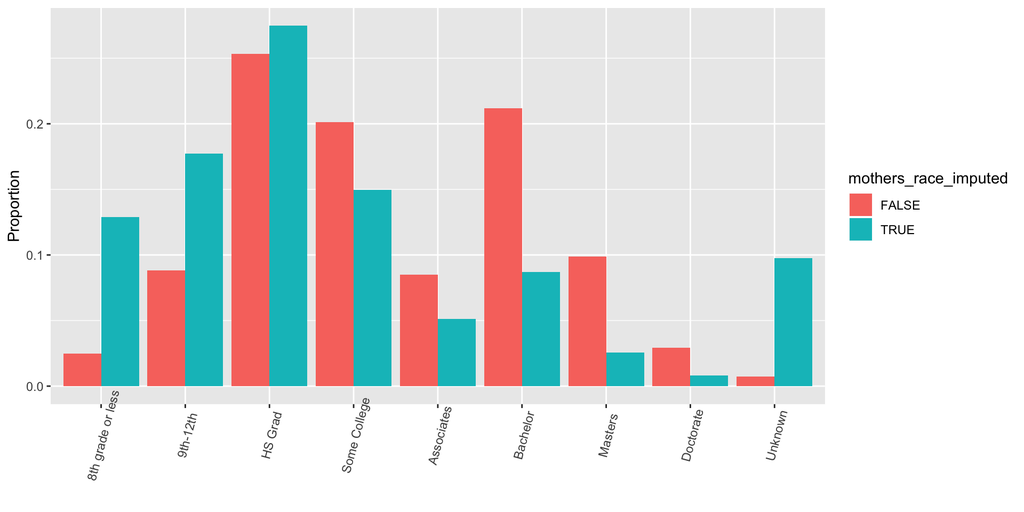

```r
nat18 %>%
      group_by(mothers_education,mothers_race_imputed) %>%
      summarise(count = n()) %>%
      group_by(mothers_race_imputed) %>%
      mutate(perc_edu = count/sum(count)) %>%
      ggplot(aes(x=factor(mothers_education),
                 y=perc_edu,
                 fill = mothers_race_imputed)) +
      geom_bar(stat='identity', position = 'dodge') +
      theme(axis.text.x = element_text(angle = 75, vjust = .75)) +
      scale_x_discrete(labels=c('8th grade or less',
                                '9th-12th',
                                'HS Grad',
                                'Some College',
                                'Associates',
                                'Bachelor',
                                'Masters',
                                'Doctorate',
                                'Unknown')) +
      xlab(NULL) + ylab('Proportion')
```

##### Mother’s Nativity

The birth place of the mother, divided between **Within the US**, **Outside of the US** and **Unknown**, is weighted largely on the first two factors where the nativity is known. However, the weights are virtually flipped, where when the race is not imputed, the large majority is born within the US, but when race is imputed, the majority is born outside of the US.

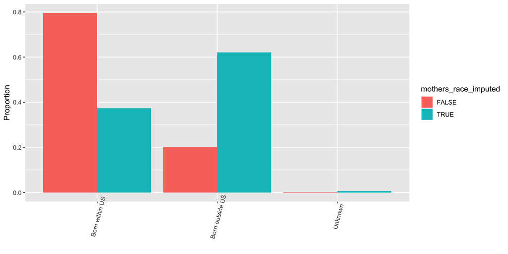

```r
nat18 %>%
      group_by(mothers_nativity,mothers_race_imputed) %>%
      summarise(count = n()) %>%
      group_by(mothers_race_imputed) %>%
      mutate(perc_nat = count/sum(count)) %>%
      ggplot(aes(x=factor(mothers_nativity),
                 y=perc_nat,
                 fill = mothers_race_imputed)) +
      geom_bar(stat='identity', position = 'dodge') +
      theme(axis.text.x = element_text(angle = 75, vjust = .75)) +
      scale_x_discrete(labels=c('Born within US','Born outside US','Unknown'))  +
      xlab(NULL) + ylab('Proportion')
```

##### Mother’s Residence Status

The final factor we discuss within this section is the mother’s residence status. The four-level feature is divided among

- **Resident**: The mother’s US state and county of residence matches that of the birthplace of the child recorded.
- **Intrastate**: The mother’s US state matches the birthplace, but the county does not.
- **Interstate**: The mother is a US resident, but the birthplace is not within the same state as her residence.
- **Foreign**: The birthplace is with in the US, but the mother is a foreign resident.

What we see below is that those mothers whose race *is* imputed are more likely to give birth in the same state and county than mothers whose race is not imputed. The difference in distribution isn’t as accented as the previous two factors we looked over, but there is a story here which is worthy of investigation. The basic observation is that mothers whose race is not imputed are more likely to give birth in a place outside their county than the imputed race group, the reason for this is where there is room for examination, and we cannot decidely say what the reason is here. However, we do offer a few possibilities, which is not exhaustive: 1) Perhaps mothers whose race is not imputed are likely to live closer to county borders and hence happen to cross the borders more often; 2) perhaps mothers whose race is not imputed *must* travel further to access a hospital; or, 3) perhaps the mothers whose race is not imputed have more choice in birthplaces and *have the opportunity* to travel to more distant hospitals if they choose.

Whatever the story may be, the fact that there is this distinction gives more evidence that these two groups are drawn from different populations.

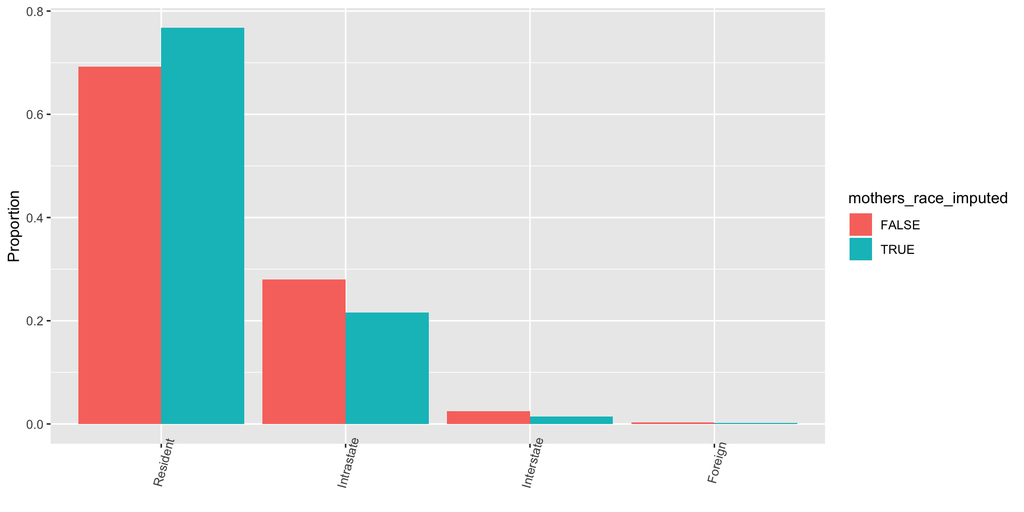

```r
nat18 %>%
      group_by(mothers_residence_status,mothers_race_imputed) %>%
      summarise(count = n()) %>%
      group_by(mothers_race_imputed) %>%
      mutate(perc_res = count/sum(count)) %>%
      ggplot(aes(x=factor(mothers_residence_status),
                 y=perc_res,
                 fill = mothers_race_imputed)) +
      geom_bar(stat='identity', position = 'dodge') +
      theme(axis.text.x = element_text(angle = 75, vjust = .8)) +
      scale_x_discrete(labels=c('Resident','Intrastate','Interstate','Foreign')) +
      xlab(NULL) + ylab('Proportion')
```

## How valid is our sample?

An important point which needs to be addressed is whether we are misrepresenting the overall population because of bias in our 10% sample. Truly, 10% randomly sampled, resulting in over 350,000 observations would very probably be a good representation of the population; however, let’s compare our original 10% sample to another, randomly drawn 10% sample. In doing so, we want to clean as we did before, so let’s start by creating a data preparation pipeline.

```r
# Create a function to follow the cleaning pipeline of the nat df
nat_prep_pipeline = function(filepath){
  require(readr)
  require(dplyr)
  # read the file into a tibble
  natdf = read_csv(filepath)
  # run through the cleaning pipeline
  natdf %>% nat_col_clean() %>% nat_fathers_race_assigned()
}

nat18_2 = nat_prep_pipeline('https://graderdata.s3.amazonaws.com/Birth18_10per2.csv')
glimpse(nat18_2)
```

```
## Rows: 380,065
## Columns: 10
## $ mothers_race_imputed     <lgl> FALSE, FALSE, FALSE, FALSE, FALSE, FALSE, FA…
## $ mothers_race6            <int> 3, 1, 1, 6, 6, 1, 1, 1, 1, 6, 1, 4, 1, 1, 1,…
## $ mothers_age              <int> 24, 29, 29, 27, 22, 31, 24, 28, 20, 37, 42, …
## $ mothers_height           <int> 61, 63, 64, 69, 63, 67, 64, 62, 62, 63, 69, …
## $ mothers_bmi              <dbl> 34.0, 39.0, 24.0, 21.4, 43.7, 21.1, 25.7, 21…
## $ mothers_nativity         <int> 1, 1, 1, 1, 1, 1, 2, 1, 1, 1, 1, 2, 1, 1, 1,…
## $ mothers_residence_status <int> 1, 1, 1, 1, 2, 1, 2, 1, 1, 1, 1, 2, 1, 1, 1,…
## $ mothers_education        <int> 4, 4, 4, 4, 3, 4, 4, 6, 3, 7, 6, 3, 5, 4, 4,…
## $ fathers_race6            <int> 9, 6, 1, 1, 9, 1, 1, 1, 1, 1, 1, 2, 1, 1, 1,…
## $ fathers_race_assigned    <lgl> FALSE, FALSE, TRUE, TRUE, FALSE, TRUE, TRUE,…
```

From above, the most telling plot is arguably the triple bar-plot, comparing the distribution of recorded race between those not imputed, those imputed from the father’s race, and those imputed without the father’s race. We will plot this again here for both samples, and see that they generally follow the same trend we previously saw. Most importantly, it is very likely that the true population has the most weight on *White* is the imputed records that did not use the father’s race.

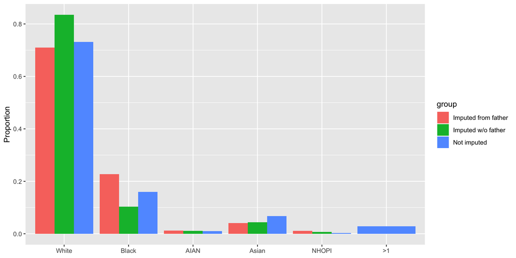

```r
# Look at the newer bar chart
compare_yn_fath_grps(nat18_2)
```

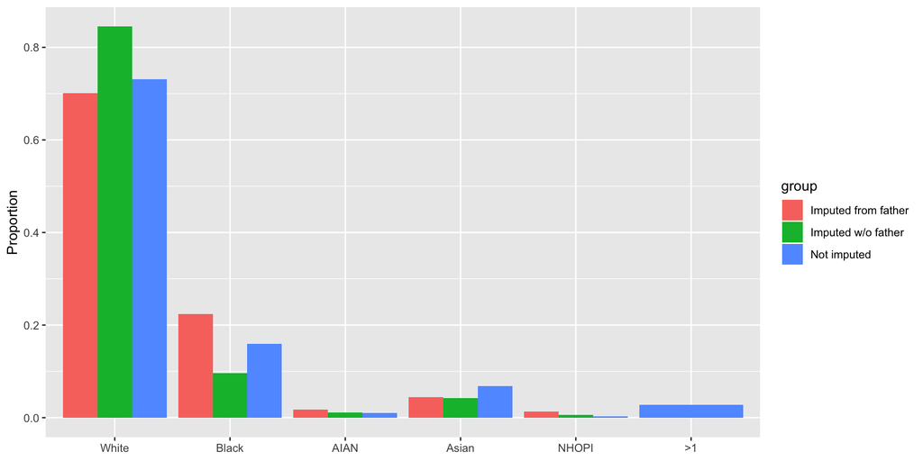

```r
# Compare to the previous
compare_yn_fath_grps(nat18)
```

We follow this up by looking at the distribution of mother’s age between the two groups. To note, we can run a much more thorough comparison on the multiple other features, which you are welcome and encouraged to do. Nonetheless, we are using this solely as additional evidence that our original sample likely caught the important trends of the full population.

1. We start by comparing the samples of motherss age when the race was imputed between the samples. We see that the KS-test suggests it is very likely drawn from the same population.

```r
ks_imp_age = ks.test_printout(nat18[nat18$mothers_race_imputed,]$mothers_age,
                              nat18_2[nat18_2$mothers_race_imputed,]$mothers_age)
```

```
## [1] "The statistic D=0.0039 with p-value=0.993195"
```

2. We continue considering the samples of mothers’ ages when the race was not imputed. Again, we would very likely not reject the null hypothesis; aka there is a reasonable chance that both samples were drawn from the same population.

```r
ks_nimp_age = ks.test_printout(nat18[!nat18$mothers_race_imputed,]$mothers_age,
                               nat18_2[!nat18_2$mothers_race_imputed,]$mothers_age)
```

```
## [1] "The statistic D=0.0022 with p-value=0.373178"
```

3. Finally, we show that in the second sample, it is very unlikely that the age distributions between imputed or not were drawn from the same population.

```r
ks_samp2_age = ks.test_printout(nat18_2[nat18_2$mothers_race_imputed,]$mothers_age,
                                nat18_2[!nat18_2$mothers_race_imputed,]$mothers_age)
```

```
## [1] "The statistic D=0.0568 with p-value=0.000000"
```

# Conclusion-ish & Exercises

There is much more work to be done here. In particular, we should consider the possible social and research impact the imputation strategy chosen by the CDC may have. Without knowing the true labels, we will not be able to *prove* their labels are wrong, but our evidence strongly suggests that it is, heavily biasing towards *White*, largely at the cost of the weight on *Black*.

### Exercises:

**Exercise 1**: Above we compared the distributions between the groups of race imputed vs race not imputed for different features. One was mothers’ ages, another was mothers’ heights. We used the KS-test to compare the distributions, however we know other statistical tests too for comparison. In this exercise:

- In a statistical sense, compare the means and variances in the different groups for the ages and heights features.
- Run a KS-test again, but first center and normalize the distributions. What more might you learn by first considering mean difference, variance differences, and then a centered and normalized KS-test?

**Exercise 2**: Suppose we created an imputation strategy for mothers whose race is not inferred from the fathers’ which followed the distribution trend seen here. What difference would that create relative to the current imputation strategy (with distribution here in the “Imputed from father” and “Imputed w/o father” levels)?

On the technical side, we have evidence that the imputation strategy might need review and considering the cost or value of creating a better imputation strategy is something we must do in many contexts.

**Exercise 3**: What might be another way of imputation and how could you have any confidence that it does a reasonable job?